# 1. GOAL OF THE REPORT

Using the California census statistics, a model of California house prices is to be constructed. This data includes information for every block group (district) in California, including population, median income, median home price, and so forth. We must forecast the median home price in the district. In order to forecast a district's median home price based on other district statistics, we must train a model. For this, we shall make use of the census information.

# 2. GETTING THE DATA

[LINK TO DATASET](https://www.kaggle.com/datasets/camnugent/california-housing-prices)

```python
import pandas as pd
import numpy as np
import matplotlib.pyplot as plt
import seaborn as sns

from sklearn import linear_model
from sklearn.metrics import mean_squared_error, mean_absolute_error
from sklearn.model_selection import train_test_split
from sklearn.linear_model import LinearRegression
from sklearn.metrics import mean_squared_error, mean_absolute_error

housing = pd.read_csv('C:/Users/HP/Downloads/Lab2_CSCN8010/data/housing.csv')
```

# 3. Exploratory Data Analysis (EDA)

3.1 EXPLORE STATISTICS

```python
housing.describe()
housing.head()
```

|  | longitude | latitude | housing_median_age | total_rooms | total_bedrooms | population | households | median_income | median_house_value | ocean_proximity |
| --- | --- | --- | --- | --- | --- | --- | --- | --- | --- | --- |
| 0 | -122.2300 | 37.8800 | 41.0000 | 880.0000 | 129.0000 | 322.0000 | 126.0000 | 8.3252 | 452600.0000 | NEAR BAY |
| 1 | -122.2200 | 37.8600 | 21.0000 | 7099.0000 | 1106.0000 | 2401.0000 | 1138.0000 | 8.3014 | 358500.0000 | NEAR BAY |
| 2 | -122.2400 | 37.8500 | 52.0000 | 1467.0000 | 190.0000 | 496.0000 | 177.0000 | 7.2574 | 352100.0000 | NEAR BAY |
| 3 | -122.2500 | 37.8500 | 52.0000 | 1274.0000 | 235.0000 | 558.0000 | 219.0000 | 5.6431 | 341300.0000 | NEAR BAY |
| 4 | -122.2500 | 37.8500 | 52.0000 | 1627.0000 | 280.0000 | 565.0000 | 259.0000 | 3.8462 | 342200.0000 | NEAR BAY |

3.2 THE FOUR VARIABLES

1. Median_Income: Describes the median income of the households
2. Population: Describes the total umber of people
3. Households: Describes the total of households
4. Median_House_Value: Describes the median house value of the households

```python
X_income = housing[['median_income']]
X_population = housing[['population']]
X_households = housing[['households']]
y = housing['median_house_value']

print(housing.isnull().sum())

print(housing.dtypes)
```

```
longitude               0
latitude                0
housing_median_age      0
total_rooms             0
total_bedrooms        207
population              0
households              0
median_income           0
median_house_value      0
ocean_proximity         0
dtype: int64
longitude             float64
latitude              float64
housing_median_age    float64
total_rooms           float64
total_bedrooms        float64
population            float64
households            float64
median_income         float64
median_house_value    float64
ocean_proximity        object
dtype: object
```

### 3.3 Seaborn scatter plots

##### Seaborn Scatter Plot of Median House Value V/s Median Income

[figure not shown]

```python
sns.scatterplot(x='median_income', y='median_house_value', data=housing)
plt.title('Seaborn Scatter Plot of Median House Value vs. Median Income')
plt.xlabel('Median Income')
plt.ylabel('Median House Value')
plt.show()
```

##### Seaborn Scatter Plot of Median House Value V/s Population

*It is observed that the median house value does not get affected by the population.*

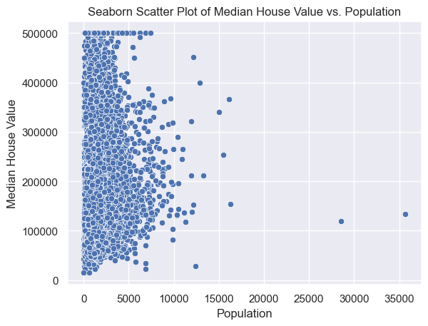

```python
sns.scatterplot(x='population', y='median_house_value', data=housing)
plt.title('Seaborn Scatter Plot of Median House Value vs. Population')
plt.xlabel('Population')
plt.ylabel('Median House Value')
plt.show()
```

##### Seaborn Scatter Plot of Median House Value V/s Number of Households

*The graph represents that the median house value was not affected by the number of households.*

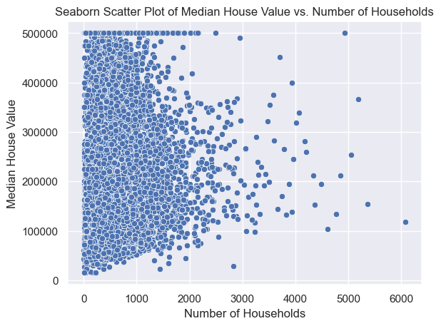

```python
sns.scatterplot(x='households', y='median_house_value', data=housing)
plt.title('Seaborn Scatter Plot of Median House Value vs. Number of Households')
plt.xlabel('Number of Households')
plt.ylabel('Median House Value')
plt.show()
```

# 4. LINEAR REGRESSIONS (FITTING)

```python
model = linear_model.LinearRegression()
```

4.1 MEDIAN HOUSE VALUE V/S MEDIAN INCOME

```python
X1 = housing[['median_income']]
y1 = housing['median_house_value']
X1_train, X1_test, y1_train, y1_test = train_test_split(X1, y1, test_size=0.2, random_state=42)

model1 = LinearRegression()
model1.fit(X1_train, y1_train)
```

```
LinearRegression()
```

4.2 MEDIAN HOUSE VALUE V/S POPULATION

```python
X2 = housing[['population']]
y2 = housing['median_house_value']
X2_train, X2_test, y2_train, y2_test = train_test_split(X2, y2, test_size=0.2, random_state=42)

model2 = LinearRegression()
model2.fit(X2_train, y2_train)
```

```
LinearRegression()
```

4.3 MEDIAN HOUSE VALUE V/S NUMBER OF HOUSEHOLDS

```python
X3 = housing[['households']]
y3 = housing['median_house_value']
X3_train, X3_test, y3_train, y3_test = train_test_split(X3, y3, test_size=0.2, random_state=42)

model3 = LinearRegression()
model3.fit(X3_train, y3_train)
```

```
LinearRegression()
```

# 5. SUMMARZISE IN A TABLE

1. Intercept and slope
2. Mean Squared Error - the loss
3. Mean Absolute Error

```python
summary_table = pd.DataFrame({
    'Model': ['Model 1', 'Model 2', 'Model 3'],
    'Intercept': [model1.intercept_, model2.intercept_, model3.intercept_],
    'Slope': [model1.coef_[0], model2.coef_[0], model3.coef_[0]],
    'Mean Squared Error': [
        mean_squared_error(y1_test, model1.predict(X1_test)),
        mean_squared_error(y2_test, model2.predict(X2_test)),
        mean_squared_error(y3_test, model3.predict(X3_test))
    ],
    'Mean Absolute Error': [
        mean_absolute_error(y1_test, model1.predict(X1_test)),
        mean_absolute_error(y2_test, model2.predict(X2_test)),
        mean_absolute_error(y3_test, model3.predict(X3_test))
    ]
})

pd.set_option('display.float_format', lambda x: '%.4f' % x)
summary_table
```

|  | Model | Intercept | Slope | Mean Squared Error | Mean Absolute Error |
| --- | --- | --- | --- | --- | --- |
| 0 | Model 1 | 44459.7292 | 41933.8494 | 7091157771.7655 | 62990.8653 |
| 1 | Model 2 | 210970.6963 | -2.6471 | 13102870667.5040 | 90588.8777 |
| 2 | Model 3 | 197526.3692 | 19.3372 | 13035578954.7830 | 90218.2581 |

# 6. PLOTTING THE RESULTING LINE

RESULTING LINE OF MEDIAN HOUSE VALUE VS. MEDIAN INCOME

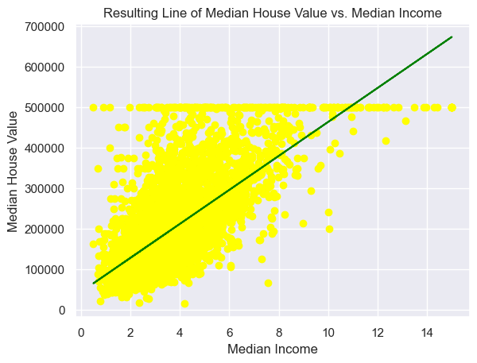

```python
plt.scatter(X1_test, y1_test, color='yellow')
plt.plot(X1_test, model1.predict(X1_test), color='green')
plt.title('Resulting Line of Median House Value vs. Median Income')
plt.xlabel('Median Income')
plt.ylabel('Median House Value')
plt.show()
```

RESULTING LINE OF MEDIAN HOUSE VALUE VS. POPULATION

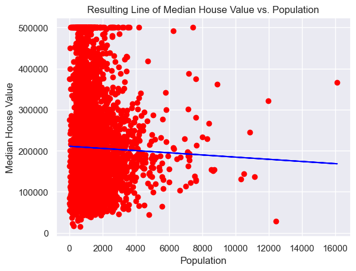

```python
plt.scatter(X2_test, y2_test, color='red')
plt.plot(X2_test, model2.predict(X2_test), color='blue')
plt.title('Resulting Line of Median House Value vs. Population')
plt.xlabel('Population')
plt.ylabel('Median House Value')
plt.show()
```

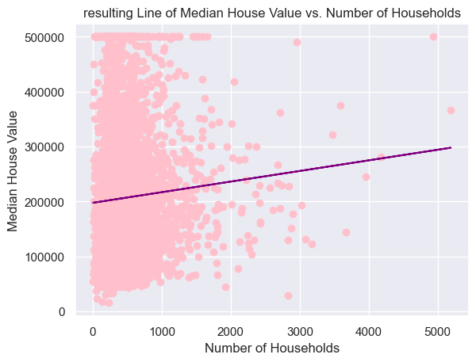

```python
plt.scatter(X3_test, y3_test, color='pink')
plt.plot(X3_test, model3.predict(X3_test), color='purple')
plt.title('resulting Line of Median House Value vs. Number of Households')
plt.xlabel('Number of Households')
plt.ylabel('Median House Value')
plt.show()
```

# CONCLUSION AND INSIGHTS